# Assignment 1: PyTorch Introduction

### Part (iv) [0.5pt EXPLORATORY]

Train `large_net` with all default parameters, including with `learning_rate=0.01`. Now, set `batch_size=16`. Does the model take longer/shorter to train? Plot the training curve. Describe the effect of *decreasing* the batch size.

```
Files already downloaded and verified
Files already downloaded and verified
Epoch 1: Train err: 0.34375, Train loss: 0.6175165125727653 |Validation err: 0.2625, Validation loss: 0.540454069852829
Epoch 2: Train err: 0.22325, Train loss: 0.4730004854500294 |Validation err: 0.2035, Validation loss: 0.43918069565296175
Epoch 3: Train err: 0.25525, Train loss: nan |Validation err: 0.4905, Validation loss: nan
Epoch 4: Train err: 0.502375, Train loss: nan |Validation err: 0.4905, Validation loss: nan
Epoch 5: Train err: 0.502375, Train loss: nan |Validation err: 0.4905, Validation loss: nan
Epoch 6: Train err: 0.502375, Train loss: nan |Validation err: 0.4905, Validation loss: nan
Epoch 7: Train err: 0.502375, Train loss: nan |Validation err: 0.4905, Validation loss: nan
Epoch 8: Train err: 0.502375, Train loss: nan |Validation err: 0.4905, Validation loss: nan
Epoch 9: Train err: 0.502375, Train loss: nan |Validation err: 0.4905, Validation loss: nan
Epoch 10: Train err: 0.502375, Train loss: nan |Validation err: 0.4905, Validation loss: nan
Epoch 11: Train err: 0.502375, Train loss: nan |Validation err: 0.4905, Validation loss: nan
Epoch 12: Train err: 0.502375, Train loss: nan |Validation err: 0.4905, Validation loss: nan
Epoch 13: Train err: 0.502375, Train loss: nan |Validation err: 0.4905, Validation loss: nan
Epoch 14: Train err: 0.502375, Train loss: nan |Validation err: 0.4905, Validation loss: nan
Epoch 15: Train err: 0.502375, Train loss: nan |Validation err: 0.4905, Validation loss: nan
Epoch 16: Train err: 0.502375, Train loss: nan |Validation err: 0.4905, Validation loss: nan
Epoch 17: Train err: 0.502375, Train loss: nan |Validation err: 0.4905, Validation loss: nan
Epoch 18: Train err: 0.502375, Train loss: nan |Validation err: 0.4905, Validation loss: nan
Epoch 19: Train err: 0.502375, Train loss: nan |Validation err: 0.4905, Validation loss: nan
Epoch 20: Train err: 0.502375, Train loss: nan |Validation err: 0.4905, Validation loss: nan
Epoch 21: Train err: 0.502375, Train loss: nan |Validation err: 0.4905, Validation loss: nan
Epoch 22: Train err: 0.502375, Train loss: nan |Validation err: 0.4905, Validation loss: nan
Epoch 23: Train err: 0.502375, Train loss: nan |Validation err: 0.4905, Validation loss: nan
Epoch 24: Train err: 0.502375, Train loss: nan |Validation err: 0.4905, Validation loss: nan
Epoch 25: Train err: 0.502375, Train loss: nan |Validation err: 0.4905, Validation loss: nan
Epoch 26: Train err: 0.502375, Train loss: nan |Validation err: 0.4905, Validation loss: nan
Epoch 27: Train err: 0.502375, Train loss: nan |Validation err: 0.4905, Validation loss: nan
Epoch 28: Train err: 0.502375, Train loss: nan |Validation err: 0.4905, Validation loss: nan
Epoch 29: Train err: 0.502375, Train loss: nan |Validation err: 0.4905, Validation loss: nan
Epoch 30: Train err: 0.502375, Train loss: nan |Validation err: 0.4905, Validation loss: nan
Finished Training
Total time elapsed: 218.68 seconds
```

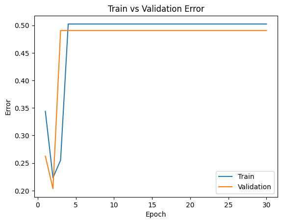

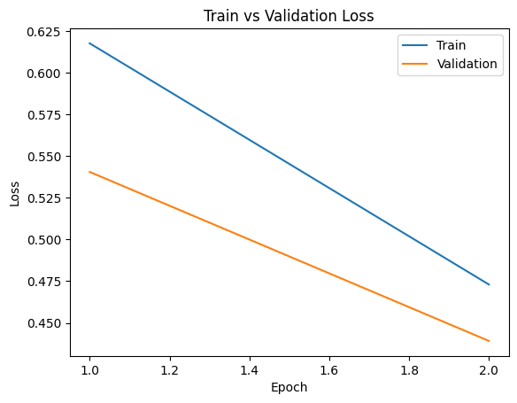

```python
# TO BE COMPLETED

'''
-----------------------------------------------------------------------------
Abdullah:
Below is the code to train a large_net with batch size = 16 and then
plotting the respective erros and losses.
-----------------------------------------------------------------------------
'''
# Create an instance of LargeNet
large_net = LargeNet()

# Train LargeNet with decreased batch size
train_net(large_net, batch_size=16)

# Plot the training curve
model_path_large_bs_16 = get_model_name("large", batch_size=16,
                                        learning_rate=0.01, epoch=29)

plot_training_curve(model_path_large_bs_16)
```

```python
'''
PROVIDE YOUR ANSWER BELOW
---------------------------------------------------------------------------

Abdullah: Replying to

"Train large_net with all default parameters, including with learning_rate=0.01
Now, set batch_size=16. Does the model take longer/shorter to train? Plot
the training curve. Describe the effect of decreasing the batch size."

Ans:

Effect of Decreasing Batch Size on Training:

Numerical Instability: The model trained with a batch size of 16 encounters
numerical instability issues, as indicated by NaN (Not a Number) values in
both training and validation losses. This is likely due to the small
batch size causing unstable weight updates and loss calculations.

The training process becomes ineffective and fails to provide meaningful
updates to the model's parameters. NaN values in the losses indicate that the
optimization process breaks down.


Convergence Failure: The model fails to converge due to the small batch size,
resulting in NaN values in the loss calculations. This is in stark contrast to
the more stable convergence observed with larger batch sizes.

The model trained with a batch size of 16 is not usable for making predictions
or drawing insights, as the training process did not effectively optimize the
model parameters.

---------------------------------------------------------------------------
'''
```

## Part 4. Hyperparameter Search

### Part (i) [1pt EXPLORATORY]

Based on the plots from above, choose another set of values for the hyperparameters (network, batch_size, learning_rate) that you think would help you improve the validation accuracy. Justify your choice.

```python
'''
PROVIDE YOUR ANSWER BELOW
----------------------------------------------------------------

Abdullah: Replying to
" Based on the plots from above, choose another set of values for the
hyperparameters (network, batch_size, learning_rate) that you think would
help you improve the validation accuracy. Justify your choice. "


Batch Size 128:
This is chosen as a middle-point between the batch sizes 64 and 512.
A smaller batch size allows for more frequent weight updates, aiding
convergence, while avoiding the potential overfitting observed with a
larger batch size.

Learning Rate 0.001:
Considering the observed smoother convergence and more stable training with
a lower learning rate, 0.001 is retained to avoid overshooting
and facilitate consistent improvement over epochs.

Network Choice (LargeNet):
The architecture of LargeNet is retained, as it provides a better behaviour
as compared to smallNet. Moreover, all the previous experiments are done using
the LargeNet network and the observations are in accordance with this network.

New hyperparameters aim to find a balance between stability,
convergence speed, and potential overfitting, based on the insights gained
from the analysis of previous experiments.
----------------------------------------------------------------

'''
```

### Part (ii) [0.5pt EXPLORATORY]

Train the model with the hyperparameters you chose in part(i), and include the training curve.

```
Files already downloaded and verified
Files already downloaded and verified
Epoch 1: Train err: 0.473375, Train loss: 0.692377834093003 |Validation err: 0.4525, Validation loss: 0.6920540854334831
Epoch 2: Train err: 0.43825, Train loss: 0.6919803099026756 |Validation err: 0.412, Validation loss: 0.6917221210896969
Epoch 3: Train err: 0.406875, Train loss: 0.6915274650331528 |Validation err: 0.3985, Validation loss: 0.6913037113845348
Epoch 4: Train err: 0.407625, Train loss: 0.6909704463822501 |Validation err: 0.4005, Validation loss: 0.6908433176577091
Epoch 5: Train err: 0.393625, Train loss: 0.6902486672477116 |Validation err: 0.3905, Validation loss: 0.6900882981717587
Epoch 6: Train err: 0.392875, Train loss: 0.6892632198712182 |Validation err: 0.383, Validation loss: 0.6891472935676575
Epoch 7: Train err: 0.381875, Train loss: 0.6879238921498495 |Validation err: 0.3775, Validation loss: 0.6878116019070148
Epoch 8: Train err: 0.379375, Train loss: 0.6860832808509706 |Validation err: 0.385, Validation loss: 0.6857129670679569
Epoch 9: Train err: 0.370125, Train loss: 0.6833200010042342 |Validation err: 0.381, Validation loss: 0.6829151511192322
Epoch 10: Train err: 0.36875, Train loss: 0.6794958199773516 |Validation err: 0.3745, Validation loss: 0.6791828572750092
Epoch 11: Train err: 0.365125, Train loss: 0.67451093215791 |Validation err: 0.372, Validation loss: 0.6747768074274063
Epoch 12: Train err: 0.362875, Train loss: 0.668324505525922 |Validation err: 0.371, Validation loss: 0.6693565770983696
Epoch 13: Train err: 0.365875, Train loss: 0.6615618051044525 |Validation err: 0.375, Validation loss: 0.6641814224421978
Epoch 14: Train err: 0.366, Train loss: 0.6555727597266908 |Validation err: 0.379, Validation loss: 0.6607329472899437
Epoch 15: Train err: 0.366625, Train loss: 0.6504262335716732 |Validation err: 0.3775, Validation loss: 0.65693673864007
Epoch 16: Train err: 0.36575, Train loss: 0.6468967341241383 |Validation err: 0.3715, Validation loss: 0.655894186347723
Epoch 17: Train err: 0.36275, Train loss: 0.6429532794725328 |Validation err: 0.375, Validation loss: 0.6528305374085903
Epoch 18: Train err: 0.360875, Train loss: 0.6402641913247487 |Validation err: 0.369, Validation loss: 0.6516817584633827
Epoch 19: Train err: 0.36175, Train loss: 0.6376030653242081 |Validation err: 0.362, Validation loss: 0.6484087221324444
Epoch 20: Train err: 0.357875, Train loss: 0.6345014127473982 |Validation err: 0.3685, Validation loss: 0.6450373232364655
Epoch 21: Train err: 0.355875, Train loss: 0.6317150403582861 |Validation err: 0.359, Validation loss: 0.6434656418859959
Epoch 22: Train err: 0.35375, Train loss: 0.6280592802971129 |Validation err: 0.3665, Validation loss: 0.6395998820662498
Epoch 23: Train err: 0.352875, Train loss: 0.6248629991970365 |Validation err: 0.3585, Validation loss: 0.6366467736661434
Epoch 24: Train err: 0.350875, Train loss: 0.6218098042503236 |Validation err: 0.36, Validation loss: 0.6341261528432369
Epoch 25: Train err: 0.34875, Train loss: 0.6184021688642956 |Validation err: 0.3545, Validation loss: 0.6303194910287857
Epoch 26: Train err: 0.347125, Train loss: 0.6144285892683362 |Validation err: 0.358, Validation loss: 0.6266509220004082
Epoch 27: Train err: 0.344125, Train loss: 0.611723300010439 |Validation err: 0.3525, Validation loss: 0.6219188049435616
Epoch 28: Train err: 0.339875, Train loss: 0.607390062203483 |Validation err: 0.3495, Validation loss: 0.618380956351757
Epoch 29: Train err: 0.33775, Train loss: 0.6031292232256087 |Validation err: 0.3435, Validation loss: 0.6134427636861801
Epoch 30: Train err: 0.329125, Train loss: 0.5991704038211277 |Validation err: 0.331, Validation loss: 0.6091822683811188
Finished Training
Total time elapsed: 137.24 seconds
```

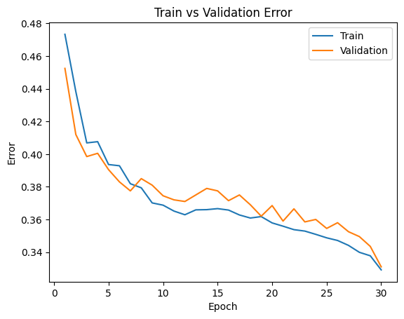

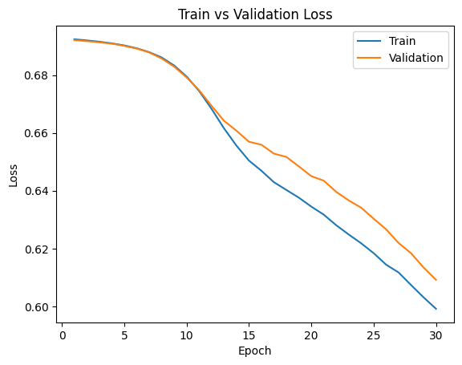

```python
# TO BE COMPLETED

# Create an instance of LargeNet
large_net = LargeNet()

# Train LargeNet with adjusted hyperparameters
train_net(large_net, batch_size=128, learning_rate=0.001, num_epochs=30)

# Plot the training curve
model_path_large_tuned = get_model_name("large", batch_size=128,
                                        learning_rate=0.001, epoch=29)

plot_training_curve(model_path_large_tuned)
```

### Part (iii) [1pt EXPLORATORY]

Based on your result from Part(i), suggest another set of hyperparameter values to try. Justify your choice.

```python
'''
PROVIDE YOUR ANSWER BELOW
---------------------------------------------------------------------------

Abdullah:

Network Architecture:

The "large" network is chosen for hyperparameter tuning, as it consistently
demonstrated better performance in capturing the complexities of the dataset
compared to the "small" network.

Batch Size of 256:

A batch size of 256 is larger than 128 but smaller than 512, providing a
middle ground. Larger batch sizes often lead to more stable convergence
compared to smaller sizes, potentially speeding up the training process.
Considering the potential overfitting with very large batch sizes, 256 is
a reasonable choice.

Learning Rate of 0.0001:

A lower learning rate (0.0001) is chosen to explore a more fine-grained
search in the parameter space.
Lower learning rates generally result in slower but more precise convergence.
This can be beneficial, especially in avoiding overshooting and achieving a
more optimal set of weights when the batch size is increased to 256.
The choice of 0.0001 is based on the trend observed with 0.001,
aiming for even smaller weight updates but with the bigger batch size.

---------------------------------------------------------------------------


'''
```

### Part (iv) [0.5pt EXPLORATORY]

Train the model with the hyperparameters you chose in part(iii), and include the training curve.

```
Files already downloaded and verified
Files already downloaded and verified
Epoch 1: Train err: 0.487, Train loss: 0.6924977637827396 |Validation err: 0.4725, Validation loss: 0.6922570988535881
Epoch 2: Train err: 0.485875, Train loss: 0.6924589928239584 |Validation err: 0.472, Validation loss: 0.6922531276941299
Epoch 3: Train err: 0.484, Train loss: 0.6924718171358109 |Validation err: 0.4715, Validation loss: 0.6922121867537498
Epoch 4: Train err: 0.48125, Train loss: 0.6924638859927654 |Validation err: 0.4715, Validation loss: 0.692209042608738
Epoch 5: Train err: 0.479375, Train loss: 0.6924451813101768 |Validation err: 0.473, Validation loss: 0.6921864151954651
Epoch 6: Train err: 0.476875, Train loss: 0.692386019974947 |Validation err: 0.4715, Validation loss: 0.6922009140253067
Epoch 7: Train err: 0.475375, Train loss: 0.6923769637942314 |Validation err: 0.47, Validation loss: 0.6921804994344711
Epoch 8: Train err: 0.47275, Train loss: 0.692345267161727 |Validation err: 0.47, Validation loss: 0.6921696364879608
Epoch 9: Train err: 0.4715, Train loss: 0.6923587527126074 |Validation err: 0.468, Validation loss: 0.6921481043100357
Epoch 10: Train err: 0.46875, Train loss: 0.6923949252814054 |Validation err: 0.467, Validation loss: 0.6921370550990105
Epoch 11: Train err: 0.465375, Train loss: 0.6923203468322754 |Validation err: 0.4645, Validation loss: 0.6921168342232704
Epoch 12: Train err: 0.464375, Train loss: 0.6922634858638048 |Validation err: 0.4635, Validation loss: 0.6921126618981361
Epoch 13: Train err: 0.461875, Train loss: 0.6922664772719145 |Validation err: 0.459, Validation loss: 0.692088283598423
Epoch 14: Train err: 0.46075, Train loss: 0.6922615524381399 |Validation err: 0.4555, Validation loss: 0.692095011472702
Epoch 15: Train err: 0.46075, Train loss: 0.6922558378428221 |Validation err: 0.4555, Validation loss: 0.6920735687017441
Epoch 16: Train err: 0.458625, Train loss: 0.6922114100307226 |Validation err: 0.452, Validation loss: 0.6920365020632744
Epoch 17: Train err: 0.456625, Train loss: 0.6921580601483583 |Validation err: 0.4485, Validation loss: 0.6920391023159027
Epoch 18: Train err: 0.4565, Train loss: 0.6921374350786209 |Validation err: 0.4475, Validation loss: 0.6920213103294373
Epoch 19: Train err: 0.454, Train loss: 0.6921650897711515 |Validation err: 0.4445, Validation loss: 0.6920164972543716
Epoch 20: Train err: 0.4515, Train loss: 0.6921538896858692 |Validation err: 0.4415, Validation loss: 0.6919969171285629
Epoch 21: Train err: 0.448125, Train loss: 0.6921251676976681 |Validation err: 0.4405, Validation loss: 0.691995695233345
Epoch 22: Train err: 0.44475, Train loss: 0.692117802798748 |Validation err: 0.44, Validation loss: 0.691977970302105
Epoch 23: Train err: 0.442375, Train loss: 0.6920620538294315 |Validation err: 0.439, Validation loss: 0.691955529153347
Epoch 24: Train err: 0.440875, Train loss: 0.6920632869005203 |Validation err: 0.438, Validation loss: 0.6919298395514488
Epoch 25: Train err: 0.439125, Train loss: 0.6919983718544245 |Validation err: 0.441, Validation loss: 0.6919207125902176
Epoch 26: Train err: 0.436, Train loss: 0.6919877026230097 |Validation err: 0.437, Validation loss: 0.6919044926762581
Epoch 27: Train err: 0.437, Train loss: 0.6919784229248762 |Validation err: 0.433, Validation loss: 0.6918746903538704
Epoch 28: Train err: 0.434625, Train loss: 0.6919945701956749 |Validation err: 0.4305, Validation loss: 0.6918598935008049
Epoch 29: Train err: 0.4315, Train loss: 0.6919220741838217 |Validation err: 0.426, Validation loss: 0.691859558224678
Epoch 30: Train err: 0.43, Train loss: 0.6919139828532934 |Validation err: 0.423, Validation loss: 0.6918537765741348
Finished Training
Total time elapsed: 132.80 seconds
```

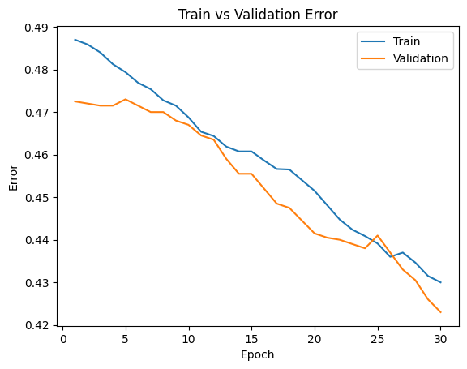

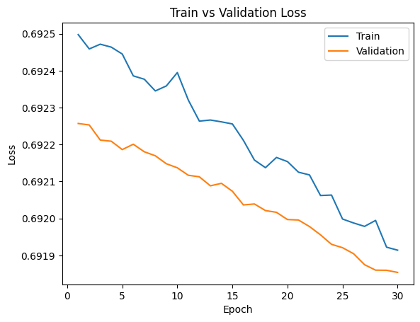

```python
# TO BE COMPLETED

# Create an instance of LargeNet
large_net = LargeNet()

# Train LargeNet with adjusted hyperparameters
train_net(large_net, batch_size=256, learning_rate=0.0001, num_epochs=30)

# Plot the training curve
model_path_large_tuned_new = get_model_name("large", batch_size=256,
                                            learning_rate=0.0001, epoch=29)
plot_training_curve(model_path_large_tuned_new)
```

## Part 4. Evaluating the Best Model

### Part (i) [2pt MODEL]

Summarize in a table the results achieved on training and validation on all your model selections. This includes choice of `small_net` vs `large_net`, the `batch_size`, `learning_rate`, **and the epoch number**. Hint: you can import the Pandas module to create tables.

Then upon reviewing the results choose your **best** model and load the model checkpoint. You can modify the code below to load your chosen set of weights to the model object `net`.

```python
net = #small or large network
model_path = get_model_name(net.name, batch_size=64, learning_rate=0.01, epoch=10)
state = torch.load(model_path)
net.load_state_dict(state)
```

```python
'''
Abdullah:

This is the code to read all the errors and make
respective dataframes in a table form. The explanation of this code is provided
in the next cell.

Epoch number is the row number of the dataframe.


'''

import pandas as pd

# Load CSV files for each model
train_error_df = pd.DataFrame({
    "small_64_01": pd.read_csv("model_small_bs64_lr0.01_epoch29_train_err.csv",
                            header=None).values.flatten(),
    "large_64_01": pd.read_csv("model_large_bs64_lr0.01_epoch29_train_err.csv",
                            header=None).values.flatten(),
    "large_64_001": pd.read_csv("model_large_bs64_lr0.001_epoch29_train_err.csv",
                            header=None).values.flatten(),
    "large_64_1": pd.read_csv("model_large_bs64_lr0.1_epoch29_train_err.csv",
                            header=None).values.flatten(),
    "large_512_01": pd.read_csv("model_large_bs512_lr0.01_epoch29_train_err.csv",
                            header=None).values.flatten(),
    "large_16_01": pd.read_csv("model_large_bs16_lr0.01_epoch29_train_err.csv",
                            header=None).values.flatten(),
    "large_128_001": pd.read_csv("model_large_bs128_lr0.001_epoch29_train_err.csv",
                            header=None).values.flatten(),
    "large_256_0001": pd.read_csv("model_large_bs256_lr0.0001_epoch29_train_err.csv",
                            header=None).values.flatten(),
})

val_error_df = pd.DataFrame({
    "small_64_01": pd.read_csv("model_small_bs64_lr0.01_epoch29_val_err.csv",
                            header=None).values.flatten(),
    "large_64_01": pd.read_csv("model_large_bs64_lr0.01_epoch29_val_err.csv",
                            header=None).values.flatten(),
    "large_64_001": pd.read_csv("model_large_bs64_lr0.001_epoch29_val_err.csv",
                            header=None).values.flatten(),
    "large_64_1": pd.read_csv("model_large_bs64_lr0.1_epoch29_val_err.csv",
                            header=None).values.flatten(),
    "large_512_01": pd.read_csv("model_large_bs512_lr0.01_epoch29_val_err.csv",
                            header=None).values.flatten(),
    "large_16_01": pd.read_csv("model_large_bs16_lr0.01_epoch29_val_err.csv",
                            header=None).values.flatten(),
    "large_128_001": pd.read_csv("model_large_bs128_lr0.001_epoch29_val_err.csv",
                            header=None).values.flatten(),
    "large_256_0001": pd.read_csv("model_large_bs256_lr0.0001_epoch29_val_err.csv",
                            header=None).values.flatten(),
})


# Find the indices (row and column) of the minimum value in val_error_df
min_val_error_index = val_error_df.unstack().idxmin()

# Extract epoch and model from the index
min_val_error_model, min_val_error_epoch = min_val_error_index

# Find the minimum validation error value
min_val_error = val_error_df.min().min()

print(f"Minimum Validation Error: {min_val_error}")
print(f"Epoch: {min_val_error_epoch}")
print(f"Model: {min_val_error_model}")

# Find the indices (row and column) of the minimum value in train_error_df
min_train_error_index = train_error_df.unstack().idxmin()

# Extract epoch and model from the index
min_train_error_model,min_train_error_epoch = min_train_error_index

# Find the minimum train error value
min_train_error = train_error_df.min().min()

print(f"Minimum Train Error: {min_train_error}")
print(f"Epoch: {min_train_error_epoch}")
print(f"Model: {min_train_error_model}")

#------------------------------------------------------------------------
net = LargeNet()
model_path = get_model_name(net.name, batch_size=64, learning_rate=0.01,
                            epoch=27)
state = torch.load(model_path)
net.load_state_dict(state)


print("\nShowing some samples from validation error dataframe")
val_error_df.head()
```

```
Minimum Validation Error: 0.119
Epoch: 27
Model: large_64_01
Minimum Train Error: 0.035
Epoch: 28
Model: large_64_01

Showing some samples from validation error dataframe
```

|  | small_64_01 | large_64_01 | large_64_001 | large_64_1 | large_512_01 | large_16_01 | large_128_001 | large_256_0001 |
| --- | --- | --- | --- | --- | --- | --- | --- | --- |
| 0 | 0.3415 | 0.3755 | 0.5095 | 0.2655 | 0.4400 | 0.2625 | 0.4525 | 0.4725 |
| 1 | 0.2875 | 0.3275 | 0.5055 | 0.2255 | 0.4030 | 0.2035 | 0.4120 | 0.4720 |
| 2 | 0.2540 | 0.2620 | 0.4365 | 0.1960 | 0.3925 | 0.4905 | 0.3985 | 0.4715 |
| 3 | 0.2440 | 0.2060 | 0.3750 | 0.1930 | 0.3930 | 0.4905 | 0.4005 | 0.4715 |
| 4 | 0.2190 | 0.1880 | 0.3830 | 0.1765 | 0.3740 | 0.4905 | 0.3905 | 0.4730 |